# Análise de dados do spotify

[curso-r](https://curso-r.com/)

3/23/2022

# Sobre este trabalho

Este documento analisa 32833 [músicas extraídas do Spotify](https://raw.githubusercontent.com/rfordatascience/tidytuesday/master/data/2020/2020-01-21/spotify_songs.csv) com os objetivos de:

1. Identificar o que torna uma música popular;
2. Identificar diferenças técnicas entre as músicas de diferentes gêneros musicais.

Nas seção 2 discutiremos o primeiro objetivo acima e na seção 3 vamos analisar os gêneros musicais. Vamos utilizar como método principal de investigação análises descritivas tais como gráfico, tabelas e cálculo de sumários e, na última seção, vamos organizar as conclusões do estudo.

## Dados analisados

| track_id | track_name | track_artist | track_popularity | track_album_id | track_album_name | track_album_release_date | playlist_name | playlist_id | playlist_genre | playlist_subgenre | danceability | energy | key | loudness | mode | speechiness | acousticness | instrumentalness | liveness | valence | tempo | duration_ms |
| --- | --- | --- | --- | --- | --- | --- | --- | --- | --- | --- | --- | --- | --- | --- | --- | --- | --- | --- | --- | --- | --- | --- |
| 6f807x0ima9a1j3VPbc7VN | I Don’t Care (with Justin Bieber) - Loud Luxury Remix | Ed Sheeran | 66 | 2oCs0DGTsRO98Gh5ZSl2Cx | I Don’t Care (with Justin Bieber) [Loud Luxury Remix] | 2019-06-14 | Pop Remix | 37i9dQZF1DXcZDD7cfEKhW | pop | dance pop | 0.748 | 0.916 | 6 | -2.634 | 1 | 0.0583 | 0.1020 | 0.00e+00 | 0.0653 | 0.518 | 122.036 | 194754 |
| 0r7CVbZTWZgbTCYdfa2P31 | Memories - Dillon Francis Remix | Maroon 5 | 67 | 63rPSO264uRjW1X5E6cWv6 | Memories (Dillon Francis Remix) | 2019-12-13 | Pop Remix | 37i9dQZF1DXcZDD7cfEKhW | pop | dance pop | 0.726 | 0.815 | 11 | -4.969 | 1 | 0.0373 | 0.0724 | 4.21e-03 | 0.3570 | 0.693 | 99.972 | 162600 |
| 1z1Hg7Vb0AhHDiEmnDE79l | All the Time - Don Diablo Remix | Zara Larsson | 70 | 1HoSmj2eLcsrR0vE9gThr4 | All the Time (Don Diablo Remix) | 2019-07-05 | Pop Remix | 37i9dQZF1DXcZDD7cfEKhW | pop | dance pop | 0.675 | 0.931 | 1 | -3.432 | 0 | 0.0742 | 0.0794 | 2.33e-05 | 0.1100 | 0.613 | 124.008 | 176616 |
| 75FpbthrwQmzHlBJLuGdC7 | Call You Mine - Keanu Silva Remix | The Chainsmokers | 60 | 1nqYsOef1yKKuGOVchbsk6 | Call You Mine - The Remixes | 2019-07-19 | Pop Remix | 37i9dQZF1DXcZDD7cfEKhW | pop | dance pop | 0.718 | 0.930 | 7 | -3.778 | 1 | 0.1020 | 0.0287 | 9.40e-06 | 0.2040 | 0.277 | 121.956 | 169093 |
| 1e8PAfcKUYoKkxPhrHqw4x | Someone You Loved - Future Humans Remix | Lewis Capaldi | 69 | 7m7vv9wlQ4i0LFuJiE2zsQ | Someone You Loved (Future Humans Remix) | 2019-03-05 | Pop Remix | 37i9dQZF1DXcZDD7cfEKhW | pop | dance pop | 0.650 | 0.833 | 1 | -4.672 | 1 | 0.0359 | 0.0803 | 0.00e+00 | 0.0833 | 0.725 | 123.976 | 189052 |

# O que torna uma música popular?

Nesta seção vamos analisar quais variáveis da nossa base ajudam a discriminar as músicas muito populares das pouco populares. Antes disso, entretanto, vamos analisar o padrão geral de variação do score de popularidade.

Na tabela abaixo encontram-se algumas estatísticas que nos ajudam a qualificar o padrão de variação do score de popularidade.

| Indicador | Valor do indicador |
| --- | --- |
| Média do Score | 42,48 |
| Mediana do Score | 45,00 |
| Desvio Padrão do Score | 24,98 |
| Coeficiente de Variação | 0,59 |

Já no gráfico abaixo verifica-se que embora a média e a mediana do score fiquem em torno de 45 pontos, existe uma concentração ao redor do 0 também.

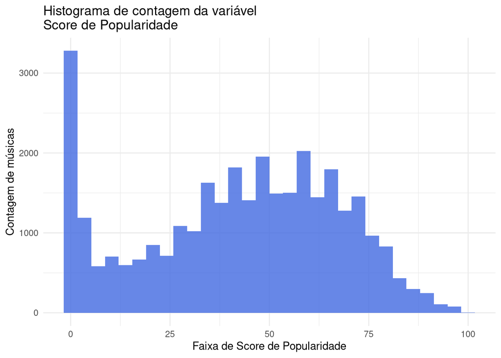

Histograma de contagem da variável Score de Popularidade. Neste gráfico nota-se que os scores se concentram ao longo do 50%, mas também há um pico significativo de músicas com Score aproximadamente zerado.

Agora que qualificamos o perfil de variação da varável Score de Popularidade, vamos partir para uma análise da relação desta variável com as demais da base. Vamos começar identificando ou não uma relação com da varíavel Score com o ano de lançamento da música.

No gráfico nota-se uma tendência de queda na popularidade média das músicas ao longo do tempo, mas com uma retomada íngreme a partir de 2010.

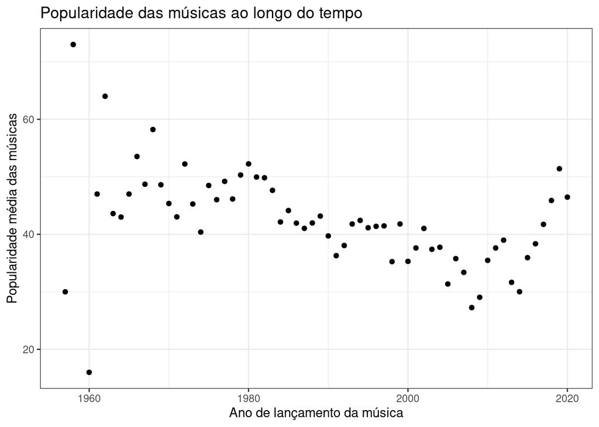

Série histórica do score médio das músicas ao longo dos anos. Neste gráfico nota-se uma queda da popularidade de 1960 até 2010 e uma retomada rápida da popularidade da década de 80 a partir de 2010..

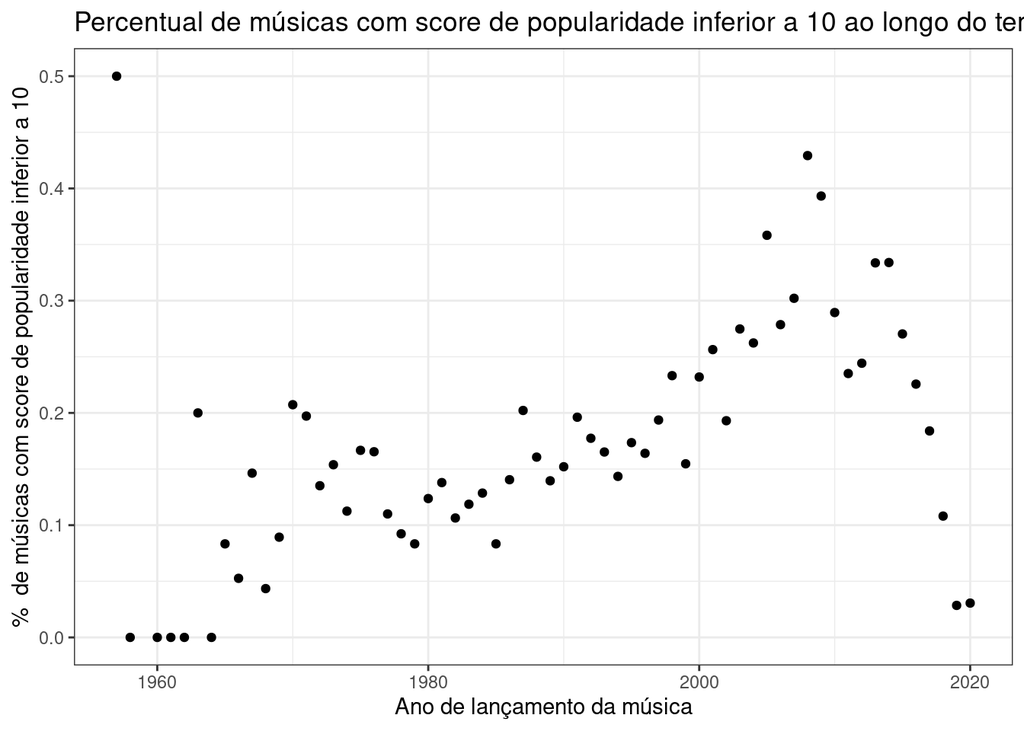

Tendo identificado que músicas lançadas em diferentes anos tem scores de popularidade bem distintos, vamos partir para a análise da variável gênero musical. Na tabela abaixo podemos comparar algumas estatísticas da popularidade associada a cada gênero. Com exceção do gênero Eletric Dance Music (EDM), o gênero musical não parece ser um fator determinante para a popularidade da música.

| Gênero Musical | Média do Score | Mediana do Score | Desvio Padrão do Score | Coeficiente de Variação |
| --- | --- | --- | --- | --- |
| EDM | 34,83 | 36,00 | 23,15 | 0,66 |
| LATIN | 47,03 | 50,00 | 25,42 | 0,54 |
| POP | 47,74 | 52,00 | 25,16 | 0,53 |
| R&B | 41,22 | 44,00 | 25,89 | 0,63 |
| RAP | 43,22 | 47,00 | 23,30 | 0,54 |
| ROCK | 41,73 | 46,00 | 24,83 | 0,59 |

A próxima variável que analisaremos será a variável artista. Entrento, na base existem 10693 pessoas. Por isso, para conseguir avaliar o impacto do artista na popularidade vamos analisar a produtividade de cada artista em número de músicas.

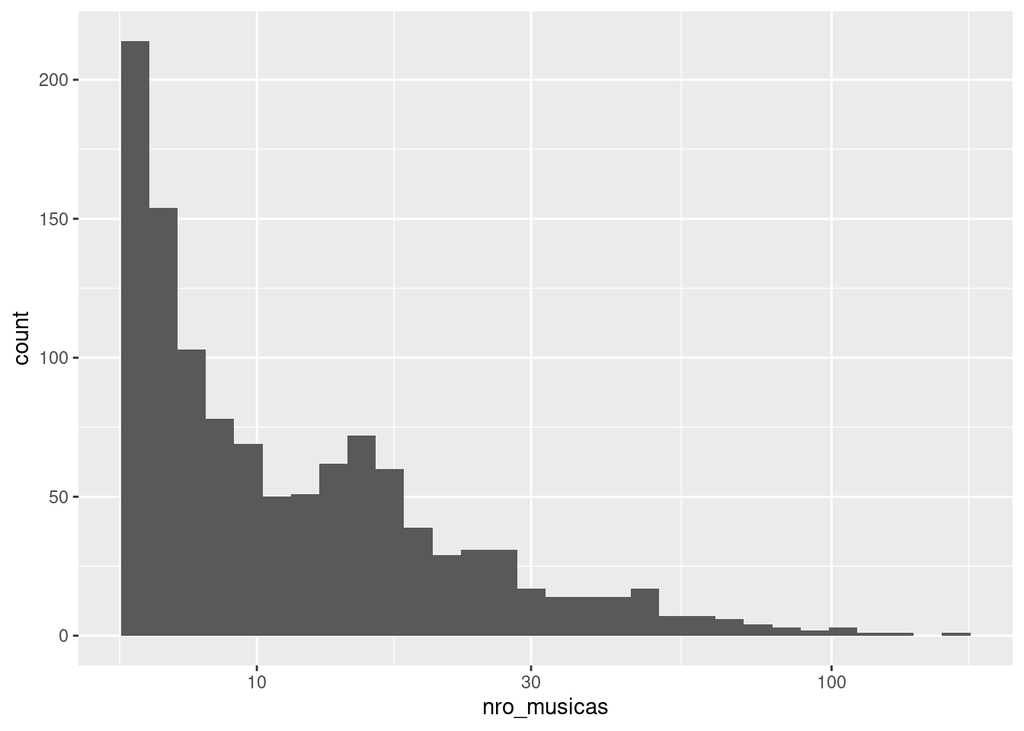